# Project 2: Video game sales analysis

## By Group 29:

- Kushal Therokar
- Vamshi Krishna Perabathula
- Khiem Doan

[figure not shown]

# 1. Objective of Project

# 2. Data Exploration

```python
import numpy as np
import pandas as pd
import matplotlib.pyplot as plt
import seaborn as sns
```

```python
#Loading the Dataset
vgsales_data=pd.read_csv('vgsales.csv')
```

```python
vgsales_data.head(10)
```

|  | Name | Year_of_Release | Genre | Publisher | NA_Sales | EU_Sales | JP_Sales | Other_Sales | Global_Sales | Critic_Score | Critic_Count | User_Score | User_Count | Developer | Rating |
| --- | --- | --- | --- | --- | --- | --- | --- | --- | --- | --- | --- | --- | --- | --- | --- |
| 0 | .hack//Infection Part 1 | 2002 | Role-Playing | Atari | 0.49 | 0.38 | 0.26 | 0.13 | 1.27 | 75 | 35 | 8.5 | 60 | CyberConnect2 | T |
| 1 | .hack//Mutation Part 2 | 2002 | Role-Playing | Atari | 0.23 | 0.18 | 0.20 | 0.06 | 0.68 | 76 | 24 | 8.9 | 81 | CyberConnect2 | T |
| 2 | .hack//Outbreak Part 3 | 2002 | Role-Playing | Atari | 0.14 | 0.11 | 0.17 | 0.04 | 0.46 | 70 | 23 | 8.7 | 19 | CyberConnect2 | T |
| 3 | [Prototype] | 2009 | Action | Activision | 0.84 | 0.35 | 0.00 | 0.12 | 1.31 | 78 | 83 | 7.8 | 356 | Radical Entertainment | M |
| 4 | [Prototype] | 2009 | Action | Activision | 0.65 | 0.40 | 0.00 | 0.19 | 1.24 | 79 | 53 | 7.7 | 308 | Radical Entertainment | M |
| 5 | [Prototype 2] | 2012 | Action | Activision | 0.48 | 0.24 | 0.00 | 0.07 | 0.79 | 74 | 69 | 7.0 | 173 | Radical Entertainment | M |
| 6 | [Prototype 2] | 2012 | Action | Activision | 0.36 | 0.28 | 0.00 | 0.10 | 0.74 | 79 | 39 | 6.8 | 179 | Radical Entertainment | M |
| 7 | [Prototype 2] | 2012 | Action | Activision | 0.07 | 0.03 | 0.00 | 0.01 | 0.11 | 76 | 12 | 6.4 | 389 | Radical Entertainment | M |
| 8 | 007: Quantum of Solace | 2008 | Action | Activision | 0.82 | 0.51 | 0.01 | 0.14 | 1.48 | 65 | 69 | 7.1 | 71 | Treyarch | T |
| 9 | 007: Quantum of Solace | 2008 | Action | Activision | 0.43 | 0.51 | 0.02 | 0.19 | 1.14 | 65 | 42 | 6.6 | 47 | Treyarch | T |

### Overview of our data

```python
overview = vgsales_data.info()
overview
```

```
<class 'pandas.core.frame.DataFrame'>
RangeIndex: 6894 entries, 0 to 6893
Data columns (total 15 columns):
 #   Column           Non-Null Count  Dtype
---  ------           --------------  -----
 0   Name             6894 non-null   object
 1   Year_of_Release  6894 non-null   int64
 2   Genre            6894 non-null   object
 3   Publisher        6893 non-null   object
 4   NA_Sales         6894 non-null   float64
 5   EU_Sales         6894 non-null   float64
 6   JP_Sales         6894 non-null   float64
 7   Other_Sales      6894 non-null   float64
 8   Global_Sales     6894 non-null   float64
 9   Critic_Score     6894 non-null   int64
 10  Critic_Count     6894 non-null   int64
 11  User_Score       6894 non-null   float64
 12  User_Count       6894 non-null   int64
 13  Developer        6890 non-null   object
 14  Rating           6826 non-null   object
dtypes: float64(6), int64(4), object(5)
memory usage: 808.0+ KB
```

The dataset contains 6,894 entries and 15 columns, with various data types including strings, integers and decimals.

```python
missing_values = vgsales_data.isnull().sum()
missing_values
```

```
Name                0
Year_of_Release     0
Genre               0
Publisher           1
NA_Sales            0
EU_Sales            0
JP_Sales            0
Other_Sales         0
Global_Sales        0
Critic_Score        0
Critic_Count        0
User_Score          0
User_Count          0
Developer           4
Rating             68
dtype: int64
```

##### There are some missing values in the dataset

- Publisher: 1 missing value
- Developer: 4 missing values
- Rating: 68 missing values

### Summary of data

```python
summary_statistics = vgsales_data.describe()
summary_statistics
```

|  | Year_of_Release | NA_Sales | EU_Sales | JP_Sales | Other_Sales | Global_Sales | Critic_Score | Critic_Count | User_Score | User_Count |
| --- | --- | --- | --- | --- | --- | --- | --- | --- | --- | --- |
| count | 6894.000000 | 6894.000000 | 6894.000000 | 6894.000000 | 6894.00000 | 6894.000000 | 6894.000000 | 6894.000000 | 6894.000000 | 6894.000000 |
| mean | 2007.482303 | 0.390920 | 0.234517 | 0.063867 | 0.08200 | 0.771487 | 70.258486 | 28.842472 | 7.184378 | 174.392370 |
| std | 4.236401 | 0.963231 | 0.684214 | 0.286461 | 0.26862 | 1.954780 | 13.861082 | 19.194572 | 1.439806 | 584.872155 |
| min | 1985.000000 | 0.000000 | 0.000000 | 0.000000 | 0.00000 | 0.010000 | 13.000000 | 3.000000 | 0.500000 | 4.000000 |
| 25% | 2004.000000 | 0.060000 | 0.020000 | 0.000000 | 0.01000 | 0.110000 | 62.000000 | 14.000000 | 6.500000 | 11.000000 |
| 50% | 2007.000000 | 0.150000 | 0.060000 | 0.000000 | 0.02000 | 0.290000 | 72.000000 | 24.000000 | 7.500000 | 27.000000 |
| 75% | 2011.000000 | 0.390000 | 0.210000 | 0.010000 | 0.07000 | 0.750000 | 80.000000 | 39.000000 | 8.200000 | 89.000000 |
| max | 2016.000000 | 41.360000 | 28.960000 | 6.500000 | 10.57000 | 82.530000 | 98.000000 | 113.000000 | 9.600000 | 10665.000000 |

##### The summary statistics for the numerical columns in the dataset provide a comprehensive view of the distribution of values across different attributes

- Year_of_Release: The games in the dataset were released between 1985 and 2016, with most of them being from the 21st century, around 2007.
- Sales (NA_Sales, EU_Sales, JP_Sales, Other_Sales, Global_Sales):
  - North America (NA_Sales) has the highest average game sales, followed by Europe (EU_Sales), Other regions (Other_Sales), and Japan (JP_Sales).
  - The most sales for a single game in North America is 41.36 million, much higher than in other places.
  - The total global sales per game vary from 0.01 million to 82.53 million, with an average of 0.77 million.
- Critic_Score: The scores given by critics range from 13 to 98, with an average score of around 70, showing that the games in the dataset were generally well-received by critics.
- Critic_Count: The number of critics reviewing a game varies from 3 to 113, with an average of around 29 critics per game.
- User_Score: The scores given by users range from 0.5 to 9.6, with an average score of around 7.18, indicating that users also generally liked the games.
- User_Count: The number of users reviewing a game ranges from 4 to 10,665, with an average of around 174 users per game. Some games received a lot more attention from users than others.

### Distribution of Video game sales

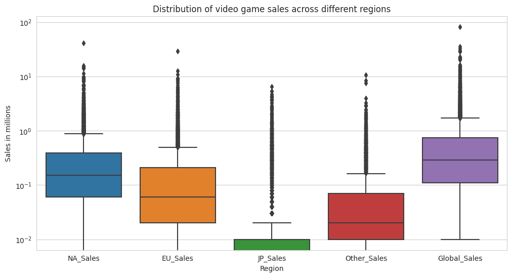

```python
sns.set_style("whitegrid")
plt.figure(figsize=(12, 6))
sns.boxplot(data=vgsales_data[['NA_Sales', 'EU_Sales', 'JP_Sales', 'Other_Sales', 'Global_Sales']])

plt.title('Distribution of video game sales across different regions')
plt.xlabel('Region')
plt.yscale('log')
plt.ylabel('Sales in millions')
plt.show()
```

The boxplot shows how video game sales are spread across different regions. To make the data easier to see, the sales numbers are shown on a special scale.

##### 1) North America (NA_Sales): Sales in North America vary a lot, meaning that some games do really well, but there are also many games that don't sell as much. Some games even sell a whole lot, way more than most others.

##### 2) Europe (EU_Sales): In Europe, sales are somewhat similar to North America, but there are fewer games that sell a whole lot more than the rest. Most games sell more consistently here.

##### 3) Japan (JP_Sales): Sales in Japan are usually lower than in North America and Europe, and the difference between how much games sell is not as big. However, there are still a few games that do exceptionally well.

##### 4) Other Regions (Other_Sales): Sales in other places around the world are like Japan, generally not as high as in North America and Europe.

##### 5) Global Sales (Global_Sales): This shows the combined sales from all regions. It has a wide range, meaning some games sell much better than others, and there are many games that do exceptionally well.

### Video game releases over time

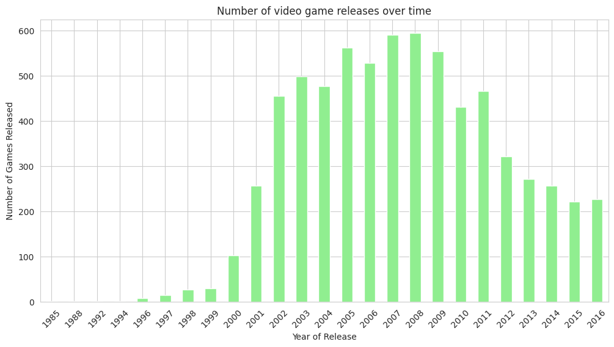

```python
plt.figure(figsize=(12, 6))
vgsales_data['Year_of_Release'].value_counts().sort_index().plot(kind='bar', color='lightgreen')

plt.title('Number of video game releases over time')
plt.xlabel('Year of Release')
plt.ylabel('Number of Games Released')
plt.xticks(rotation=45)
plt.show()
```

- The bar chart shows how many video games were released each year in the dataset.
- From 1985 to 1995, only a few games came out each year because the video game industry was just starting.
- Between 1996 and 2006, the number of yearly game releases went up a lot. This shows that the game industry was growing and getting more advanced, with better game systems and more PC games.
- From 2007 to 2016, the number of game releases went up the most around 2007 to 2009 and then started going down slowly. This might be because game systems became easier to get, mobile gaming became popular, and digital game stores came out. The drop in releases could be because the market was already full, making games cost more to make, or because people started to like different kinds of games.
- In short, this data helps us see how video game releases changed over time and gives us ideas for more detailed research about the video game market.

# 3. Data cleaning

### Removing rows with missing values

```python
cleaned_data=vgsales_data.dropna(subset=['Publisher', 'Developer', 'Rating'])
cleaned_data
```

|  | Name | Year_of_Release | Genre | Publisher | NA_Sales | EU_Sales | JP_Sales | Other_Sales | Global_Sales | Critic_Score | Critic_Count | User_Score | User_Count | Developer | Rating |
| --- | --- | --- | --- | --- | --- | --- | --- | --- | --- | --- | --- | --- | --- | --- | --- |
| 0 | .hack//Infection Part 1 | 2002 | Role-Playing | Atari | 0.49 | 0.38 | 0.26 | 0.13 | 1.27 | 75 | 35 | 8.5 | 60 | CyberConnect2 | T |
| 1 | .hack//Mutation Part 2 | 2002 | Role-Playing | Atari | 0.23 | 0.18 | 0.20 | 0.06 | 0.68 | 76 | 24 | 8.9 | 81 | CyberConnect2 | T |
| 2 | .hack//Outbreak Part 3 | 2002 | Role-Playing | Atari | 0.14 | 0.11 | 0.17 | 0.04 | 0.46 | 70 | 23 | 8.7 | 19 | CyberConnect2 | T |
| 3 | [Prototype] | 2009 | Action | Activision | 0.84 | 0.35 | 0.00 | 0.12 | 1.31 | 78 | 83 | 7.8 | 356 | Radical Entertainment | M |
| 4 | [Prototype] | 2009 | Action | Activision | 0.65 | 0.40 | 0.00 | 0.19 | 1.24 | 79 | 53 | 7.7 | 308 | Radical Entertainment | M |
| ... | ... | ... | ... | ... | ... | ... | ... | ... | ... | ... | ... | ... | ... | ... | ... |
| 6889 | Zubo | 2008 | Misc | Electronic Arts | 0.08 | 0.02 | 0.00 | 0.01 | 0.11 | 75 | 19 | 7.6 | 75 | EA Bright Light | E10+ |
| 6890 | Zumba Fitness | 2010 | Sports | 505 Games | 1.74 | 0.45 | 0.00 | 0.18 | 2.37 | 42 | 10 | 5.5 | 16 | Pipeworks Software, Inc. | E |
| 6891 | Zumba Fitness: World Party | 2013 | Misc | Majesco Entertainment | 0.17 | 0.05 | 0.00 | 0.02 | 0.24 | 73 | 5 | 6.2 | 40 | Zoe Mode | E |
| 6892 | Zumba Fitness Core | 2012 | Misc | 505 Games | 0.00 | 0.05 | 0.00 | 0.00 | 0.05 | 77 | 6 | 6.7 | 6 | Zoe Mode | E10+ |
| 6893 | Zumba Fitness Rush | 2012 | Sports | 505 Games | 0.00 | 0.16 | 0.00 | 0.02 | 0.18 | 73 | 7 | 6.2 | 5 | Majesco Games, Majesco | E10+ |

6825 rows × 15 columns

We removed rows with missing values in critical columns that are essential for analysis. In this dataset, the columns "Publisher," "Developer," and "Rating" have some missing values.

```python
cleaned_data = vgsales_data.drop_duplicates()
cleaned_data
```

|  | Name | Year_of_Release | Genre | Publisher | NA_Sales | EU_Sales | JP_Sales | Other_Sales | Global_Sales | Critic_Score | Critic_Count | User_Score | User_Count | Developer | Rating |
| --- | --- | --- | --- | --- | --- | --- | --- | --- | --- | --- | --- | --- | --- | --- | --- |
| 0 | .hack//Infection Part 1 | 2002 | Role-Playing | Atari | 0.49 | 0.38 | 0.26 | 0.13 | 1.27 | 75 | 35 | 8.5 | 60 | CyberConnect2 | T |
| 1 | .hack//Mutation Part 2 | 2002 | Role-Playing | Atari | 0.23 | 0.18 | 0.20 | 0.06 | 0.68 | 76 | 24 | 8.9 | 81 | CyberConnect2 | T |
| 2 | .hack//Outbreak Part 3 | 2002 | Role-Playing | Atari | 0.14 | 0.11 | 0.17 | 0.04 | 0.46 | 70 | 23 | 8.7 | 19 | CyberConnect2 | T |
| 3 | [Prototype] | 2009 | Action | Activision | 0.84 | 0.35 | 0.00 | 0.12 | 1.31 | 78 | 83 | 7.8 | 356 | Radical Entertainment | M |
| 4 | [Prototype] | 2009 | Action | Activision | 0.65 | 0.40 | 0.00 | 0.19 | 1.24 | 79 | 53 | 7.7 | 308 | Radical Entertainment | M |
| ... | ... | ... | ... | ... | ... | ... | ... | ... | ... | ... | ... | ... | ... | ... | ... |
| 6889 | Zubo | 2008 | Misc | Electronic Arts | 0.08 | 0.02 | 0.00 | 0.01 | 0.11 | 75 | 19 | 7.6 | 75 | EA Bright Light | E10+ |
| 6890 | Zumba Fitness | 2010 | Sports | 505 Games | 1.74 | 0.45 | 0.00 | 0.18 | 2.37 | 42 | 10 | 5.5 | 16 | Pipeworks Software, Inc. | E |
| 6891 | Zumba Fitness: World Party | 2013 | Misc | Majesco Entertainment | 0.17 | 0.05 | 0.00 | 0.02 | 0.24 | 73 | 5 | 6.2 | 40 | Zoe Mode | E |
| 6892 | Zumba Fitness Core | 2012 | Misc | 505 Games | 0.00 | 0.05 | 0.00 | 0.00 | 0.05 | 77 | 6 | 6.7 | 6 | Zoe Mode | E10+ |
| 6893 | Zumba Fitness Rush | 2012 | Sports | 505 Games | 0.00 | 0.16 | 0.00 | 0.02 | 0.18 | 73 | 7 | 6.2 | 5 | Majesco Games, Majesco | E10+ |

6894 rows × 15 columns

# 4. Adaptation

### Sales Per User column

```python
cleaned_data['Sales_Per_User'] = cleaned_data['Global_Sales'] / cleaned_data['User_Count']
cleaned_data
```

|  | Name | Year_of_Release | Genre | Publisher | NA_Sales | EU_Sales | JP_Sales | Other_Sales | Global_Sales | Critic_Score | Critic_Count | User_Score | User_Count | Developer | Rating | Sales_Per_User |
| --- | --- | --- | --- | --- | --- | --- | --- | --- | --- | --- | --- | --- | --- | --- | --- | --- |
| 0 | .hack//Infection Part 1 | 2002 | Role-Playing | Atari | 0.49 | 0.38 | 0.26 | 0.13 | 1.27 | 75 | 35 | 8.5 | 60 | CyberConnect2 | T | 0.021167 |
| 1 | .hack//Mutation Part 2 | 2002 | Role-Playing | Atari | 0.23 | 0.18 | 0.20 | 0.06 | 0.68 | 76 | 24 | 8.9 | 81 | CyberConnect2 | T | 0.008395 |
| 2 | .hack//Outbreak Part 3 | 2002 | Role-Playing | Atari | 0.14 | 0.11 | 0.17 | 0.04 | 0.46 | 70 | 23 | 8.7 | 19 | CyberConnect2 | T | 0.024211 |
| 3 | [Prototype] | 2009 | Action | Activision | 0.84 | 0.35 | 0.00 | 0.12 | 1.31 | 78 | 83 | 7.8 | 356 | Radical Entertainment | M | 0.003680 |
| 4 | [Prototype] | 2009 | Action | Activision | 0.65 | 0.40 | 0.00 | 0.19 | 1.24 | 79 | 53 | 7.7 | 308 | Radical Entertainment | M | 0.004026 |
| ... | ... | ... | ... | ... | ... | ... | ... | ... | ... | ... | ... | ... | ... | ... | ... | ... |
| 6889 | Zubo | 2008 | Misc | Electronic Arts | 0.08 | 0.02 | 0.00 | 0.01 | 0.11 | 75 | 19 | 7.6 | 75 | EA Bright Light | E10+ | 0.001467 |
| 6890 | Zumba Fitness | 2010 | Sports | 505 Games | 1.74 | 0.45 | 0.00 | 0.18 | 2.37 | 42 | 10 | 5.5 | 16 | Pipeworks Software, Inc. | E | 0.148125 |
| 6891 | Zumba Fitness: World Party | 2013 | Misc | Majesco Entertainment | 0.17 | 0.05 | 0.00 | 0.02 | 0.24 | 73 | 5 | 6.2 | 40 | Zoe Mode | E | 0.006000 |
| 6892 | Zumba Fitness Core | 2012 | Misc | 505 Games | 0.00 | 0.05 | 0.00 | 0.00 | 0.05 | 77 | 6 | 6.7 | 6 | Zoe Mode | E10+ | 0.008333 |
| 6893 | Zumba Fitness Rush | 2012 | Sports | 505 Games | 0.00 | 0.16 | 0.00 | 0.02 | 0.18 | 73 | 7 | 6.2 | 5 | Majesco Games, Majesco | E10+ | 0.036000 |

6894 rows × 16 columns

##### This column would represent the global sales per user who reviewed the game. It can be calculated by dividing the global sales by the user count. This metric could be useful to understand the relationship between sales and user engagement or satisfaction

##### This new column, Sales_Per_User, represents the global sales per user who reviewed the game. It is calculated as the ratio of Global_Sales to User_Count.

### Critic to user score ratio

```python
cleaned_data['Critic_User_Score_Ratio'] = cleaned_data['Critic_Score'] / (cleaned_data['User_Score'] *10 )
cleaned_data
```

|  | Name | Year_of_Release | Genre | Publisher | NA_Sales | EU_Sales | JP_Sales | Other_Sales | Global_Sales | Critic_Score | Critic_Count | User_Score | User_Count | Developer | Rating | Sales_Per_User | Critic_User_Score_Ratio |
| --- | --- | --- | --- | --- | --- | --- | --- | --- | --- | --- | --- | --- | --- | --- | --- | --- | --- |
| 0 | .hack//Infection Part 1 | 2002 | Role-Playing | Atari | 0.49 | 0.38 | 0.26 | 0.13 | 1.27 | 75 | 35 | 8.5 | 60 | CyberConnect2 | T | 0.021167 | 0.882353 |
| 1 | .hack//Mutation Part 2 | 2002 | Role-Playing | Atari | 0.23 | 0.18 | 0.20 | 0.06 | 0.68 | 76 | 24 | 8.9 | 81 | CyberConnect2 | T | 0.008395 | 0.853933 |
| 2 | .hack//Outbreak Part 3 | 2002 | Role-Playing | Atari | 0.14 | 0.11 | 0.17 | 0.04 | 0.46 | 70 | 23 | 8.7 | 19 | CyberConnect2 | T | 0.024211 | 0.804598 |
| 3 | [Prototype] | 2009 | Action | Activision | 0.84 | 0.35 | 0.00 | 0.12 | 1.31 | 78 | 83 | 7.8 | 356 | Radical Entertainment | M | 0.003680 | 1.000000 |
| 4 | [Prototype] | 2009 | Action | Activision | 0.65 | 0.40 | 0.00 | 0.19 | 1.24 | 79 | 53 | 7.7 | 308 | Radical Entertainment | M | 0.004026 | 1.025974 |
| ... | ... | ... | ... | ... | ... | ... | ... | ... | ... | ... | ... | ... | ... | ... | ... | ... | ... |
| 6889 | Zubo | 2008 | Misc | Electronic Arts | 0.08 | 0.02 | 0.00 | 0.01 | 0.11 | 75 | 19 | 7.6 | 75 | EA Bright Light | E10+ | 0.001467 | 0.986842 |
| 6890 | Zumba Fitness | 2010 | Sports | 505 Games | 1.74 | 0.45 | 0.00 | 0.18 | 2.37 | 42 | 10 | 5.5 | 16 | Pipeworks Software, Inc. | E | 0.148125 | 0.763636 |
| 6891 | Zumba Fitness: World Party | 2013 | Misc | Majesco Entertainment | 0.17 | 0.05 | 0.00 | 0.02 | 0.24 | 73 | 5 | 6.2 | 40 | Zoe Mode | E | 0.006000 | 1.177419 |
| 6892 | Zumba Fitness Core | 2012 | Misc | 505 Games | 0.00 | 0.05 | 0.00 | 0.00 | 0.05 | 77 | 6 | 6.7 | 6 | Zoe Mode | E10+ | 0.008333 | 1.149254 |
| 6893 | Zumba Fitness Rush | 2012 | Sports | 505 Games | 0.00 | 0.16 | 0.00 | 0.02 | 0.18 | 73 | 7 | 6.2 | 5 | Majesco Games, Majesco | E10+ | 0.036000 | 1.177419 |

6894 rows × 17 columns

##### This column would represent the ratio of the critic score to the user score. A value greater than 1 would indicate that critics rated the game more favorably than users, while a value less than 1 would indicate the opposite. This metric could be useful to identify games with significant discrepancies between critic and user opinions.

##### This new column, Critic_User_Score_Ratio, represents the ratio of the critic score to the user score. It is calculated as the ratio of Critic_Score to User_Score. Note that the User_Score has been multiplied by 10 to bring it to the same scale as the Critic_Score.

##### These additional metrics could provide valuable insights during further analysis, helping to understand the relationship between sales, user engagement, and the discrepancies between critic and user opinions.

```python
cleaned_data.describe()
```

|  | Year_of_Release | NA_Sales | EU_Sales | JP_Sales | Other_Sales | Global_Sales | Critic_Score | Critic_Count | User_Score | User_Count | Sales_Per_User | Critic_User_Score_Ratio |
| --- | --- | --- | --- | --- | --- | --- | --- | --- | --- | --- | --- | --- |
| count | 6894.000000 | 6894.000000 | 6894.000000 | 6894.000000 | 6894.00000 | 6894.000000 | 6894.000000 | 6894.000000 | 6894.000000 | 6894.000000 | 6894.000000 | 6894.000000 |
| mean | 2007.482303 | 0.390920 | 0.234517 | 0.063867 | 0.08200 | 0.771487 | 70.258486 | 28.842472 | 7.184378 | 174.392370 | 0.021227 | 1.010758 |
| std | 4.236401 | 0.963231 | 0.684214 | 0.286461 | 0.26862 | 1.954780 | 13.861082 | 19.194572 | 1.439806 | 584.872155 | 0.040043 | 0.318287 |
| min | 1985.000000 | 0.000000 | 0.000000 | 0.000000 | 0.00000 | 0.010000 | 13.000000 | 3.000000 | 0.500000 | 4.000000 | 0.000005 | 0.303371 |
| 25% | 2004.000000 | 0.060000 | 0.020000 | 0.000000 | 0.01000 | 0.110000 | 62.000000 | 14.000000 | 6.500000 | 11.000000 | 0.003507 | 0.875000 |
| 50% | 2007.000000 | 0.150000 | 0.060000 | 0.000000 | 0.02000 | 0.290000 | 72.000000 | 24.000000 | 7.500000 | 27.000000 | 0.010000 | 0.974684 |
| 75% | 2011.000000 | 0.390000 | 0.210000 | 0.010000 | 0.07000 | 0.750000 | 80.000000 | 39.000000 | 8.200000 | 89.000000 | 0.024200 | 1.075758 |
| max | 2016.000000 | 41.360000 | 28.960000 | 6.500000 | 10.57000 | 82.530000 | 98.000000 | 113.000000 | 9.600000 | 10665.000000 | 0.957500 | 12.000000 |

# 5. Descriptive Visualization

### 1. Heatmap of Correlation Matrix

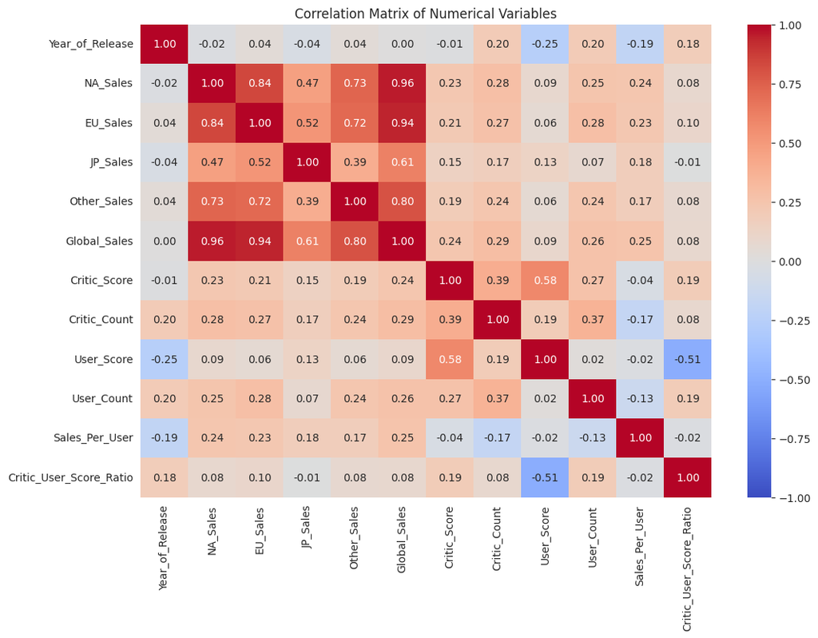

```python
plt.figure(figsize=(12, 8))
correlation_matrix = cleaned_data.corr()

sns.heatmap(correlation_matrix, annot=True, fmt=".2f", cmap='coolwarm', vmin=-1, vmax=1)
plt.title('Correlation Matrix of Numerical Variables')
plt.show()
```

##### The heatmap above depicts the correlation between different numerical variables in the dataset. Here are some key observations:

- Global Sales and Regional Sales: There are strong positive correlations between global sales and sales in individual regions (North America, Europe, Japan, and Other regions), which is expected since global sales are the sum of regional sales.
- Critic Score and User Score: There is a moderate positive correlation between critic scores and user scores, indicating that games rated highly by critics also tend to be rated highly by users.
- Sales and Review Counts: There are positive correlations between sales (both global and regional) and the number of reviews by critics and users. This suggests that more popular games tend to receive more reviews.
- Critic to User Score Ratio: The new column Critic_User_Score_Ratio has low correlation with most other variables, indicating that the discrepancy between critic and user scores does not strongly depend on other factors in the dataset.

### 2. Bar Plot of Game Releases by Genre

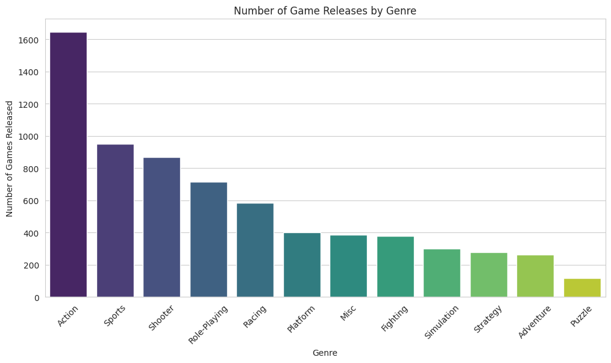

```python
plt.figure(figsize=(12, 6))
genre_counts = cleaned_data['Genre'].value_counts()
sns.barplot(x=genre_counts.index, y=genre_counts.values, palette='viridis')

plt.title('Number of Game Releases by Genre')
plt.xlabel('Genre')
plt.ylabel('Number of Games Released')
plt.xticks(rotation=45)
plt.show()
```

##### The bar plot above illustrates the number of game releases across different genres. Key observations include:

- Action and Sports: These genres have the highest number of releases, indicating their popularity among developers and publishers.
- Role-Playing and Shooter: These genres also have a significant number of releases, showcasing their appeal to a broad audience.
- Puzzle and Strategy: These genres have fewer releases compared to others, which might reflect a more niche audience or specific gameplay preferences

### 3. Scatter Plot of Global Sales vs. User Score

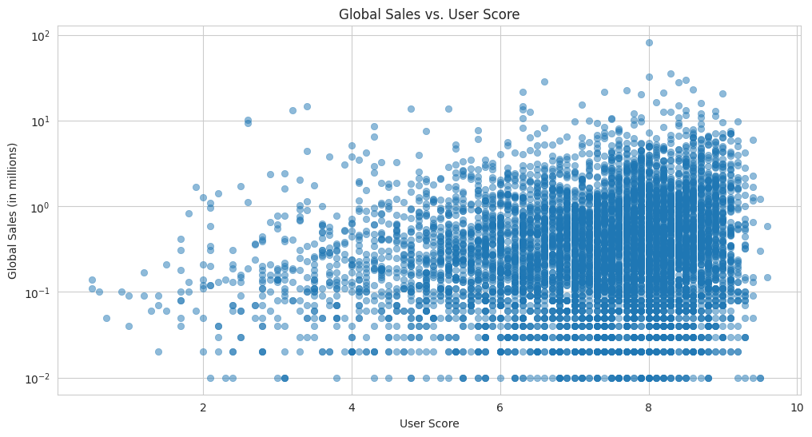

```python
plt.figure(figsize=(12, 6))
sns.scatterplot(data=cleaned_data, x='User_Score', y='Global_Sales', alpha=0.5, edgecolor=None)

plt.title('Global Sales vs. User Score')
plt.xlabel('User Score')
plt.yscale('log')
plt.ylabel('Global Sales (in millions)')
plt.show()
```

##### The scatter plot above depicts the relationship between global sales and user scores for the games in the dataset. Here are some insights:

- Broad Distribution: Games with a wide range of user scores have achieved varying levels of global sales. There isn't a clear linear relationship between user scores and sales.
- High Sales at Different Scores: There are games with both high and low user scores that have achieved high global sales, indicating that user scores are not the sole determinant of sales success.
- Concentration at Lower Sales: A large number of games, regardless of user score, have lower global sales, which is typical given the competitive nature of the gaming industry.

### 4. Box Plot of Sales Distribution by ESRB Rating

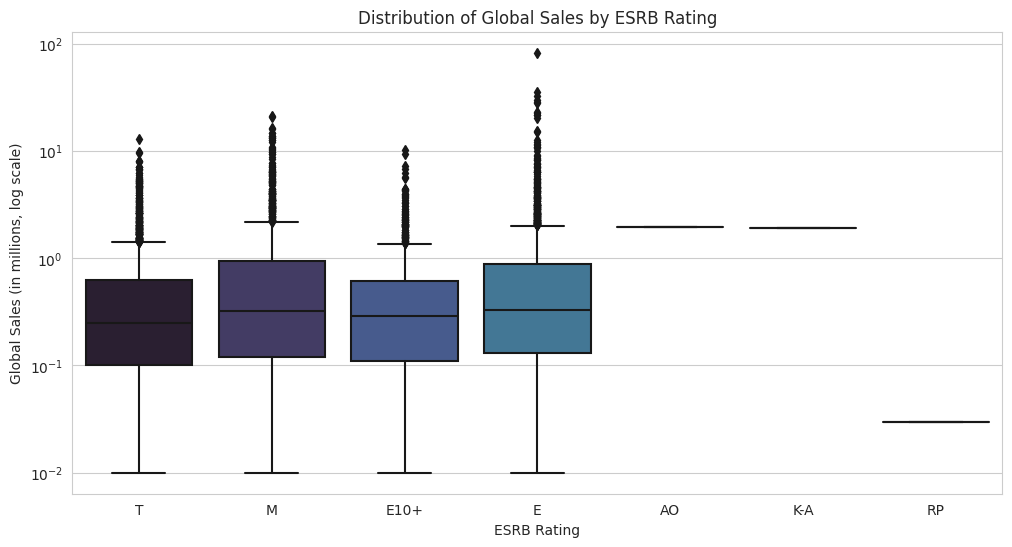

```python
plt.figure(figsize=(12, 6))
sns.boxplot(data=cleaned_data, x='Rating', y='Global_Sales', palette='mako')
plt.title('Distribution of Global Sales by ESRB Rating')
plt.xlabel('ESRB Rating')
plt.ylabel('Global Sales (in millions)')
plt.yscale('log')
plt.ylabel('Global Sales (in millions, log scale)')
plt.show()
```

### Summary of Visualizations

##### These visualizations provide a multifaceted view of the dataset, highlighting trends and patterns across different variables. Whether it's understanding the correlation between different attributes, analyzing the popularity of different genres, exploring the relationship between user scores and sales, or examining how sales are distributed across ESRB ratings, each visualization contributes to a comprehensive understanding of the video game sales landscape.

# 6. Step-by-step hierarchical clustering

##### Hierarchical clustering is a method of cluster analysis which seeks to build a hierarchy of clusters. Agglomerative hierarchical clustering is one of the methods used, where each observation starts in its own cluster, and pairs of clusters are merged as one moves up the hierarchy.

##### To perform step-by-step hierarchical clustering using the agglomerative method, we can follow these steps:

##### Preprocess the Data: Normalize the data to ensure that all variables contribute equally to the distance calculations.

##### Initialize Clusters: Start by assigning each data point to its own cluster.

##### Compute Distance Matrix: Calculate the pairwise distances between all clusters.

##### Find and Merge the Closest Clusters: Identify the two clusters that are closest to each other and merge them into a single cluster. Update the distance matrix accordingly.

##### Repeat Steps 4 and 5: Continue the process until the desired number of clusters is reached.

##### Assign Cluster Labels: Assign a cluster label to each data point based on the final clusters.

##### For this demonstration, I'll use a subset of the data and focus on numerical variables to perform the clustering. Let's start with the first step: preprocessing the data.

```python
from sklearn.preprocessing import StandardScaler
from scipy.spatial.distance import pdist, squareform
import numpy as np
import pandas as pd

# Selecting a subset of the data and focusing on numerical variables for clustering
data_subset = cleaned_data[['Global_Sales', 'Critic_Score', 'Sales_Per_User', 'Critic_User_Score_Ratio']]

# 1. Preprocess the Data: Normalize the data
scaler = StandardScaler()
data_scaled = pd.DataFrame(scaler.fit_transform(data_subset), columns=data_subset.columns)

# Display the first few rows of the scaled data
data_scaled.head()
```

|  | Global_Sales | Critic_Score | Sales_Per_User | Critic_User_Score_Ratio |
| --- | --- | --- | --- | --- |
| 0 | 0.255041 | 0.342099 | -0.001514 | -0.403455 |
| 1 | -0.046805 | 0.414248 | -0.320483 | -0.492754 |
| 2 | -0.159358 | -0.018650 | 0.074505 | -0.647766 |
| 3 | 0.275505 | 0.558548 | -0.438247 | -0.033802 |
| 4 | 0.239693 | 0.630697 | -0.429601 | 0.047809 |

##### The data has been successfully normalized, ensuring that all variables contribute equally to the distance calculations.

##### Next, we will initialize the clusters, compute the initial distance matrix, and define functions to perform the agglomerative hierarchical clustering

```python
from scipy.cluster.hierarchy import linkage, fcluster

# Step-by-step agglomerative hierarchical clustering
def hierarchical_clustering(df, max_clusters):
    # Perform hierarchical clustering
    Z = linkage(df, method='ward')

    # Initialize the current number of clusters
    current_clusters = df.shape[0]

    # Loop to merge clusters step-by-step
    for i, row in enumerate(Z):
        # Update the current number of clusters
        current_clusters -= 1

        # Print update
        print(f"Step {i+1}: Merged clusters {int(row[0])} and {int(row[1])}. Total clusters: {current_clusters}.")

        # Stop if we reach the desired number of clusters
        if current_clusters == max_clusters:
            print("Reached the target number of clusters.")
            break

    # Create cluster labels
    labels = fcluster(Z, max_clusters, criterion='maxclust')

    return labels

# Run hierarchical clustering and get labels
max_clusters = 5
labels = hierarchical_clustering(data_scaled, max_clusters=max_clusters)

# Show first few labels
labels[:10]
```

[output not shown]

##### This implementation utilizes the linkage and fcluster functions from the scipy library to perform the agglomerative hierarchical clustering and assign the data points to clusters, respectively. The ward method was used for linkage, which minimizes the variance of the clusters being merged

# 7. Dendrogram

##### Interpretation of the Dendrogram:

##### Vertical Lines: These represent the merging of clusters. The height of the vertical line indicates the distance at which the two clusters were merged. A taller line implies that the merged clusters were further apart, suggesting less similarity between them.

##### Horizontal Lines: These represent the clusters themselves. The length of the horizontal lines does not carry any specific meaning in this context.

###### Distance: The y-axis represents the distance between clusters. The dendrogram uses the Ward variance minimization algorithm, which means the distances represent the increase in variance for the merged cluster compared to the individual clusters

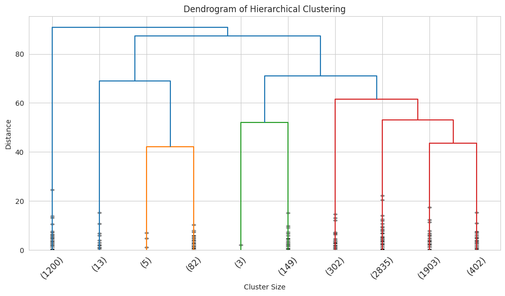

```python
from scipy.cluster.hierarchy import dendrogram
data_subset = data_scaled.copy()


# Compute linkages for hierarchical clustering
Z = linkage(data_scaled, method='ward')

# Plot the dendrogram
plt.figure(figsize=(12, 6))
dendrogram(Z, truncate_mode='lastp', p=10, leaf_rotation=45., leaf_font_size=12., show_contracted=True)
plt.title('Dendrogram of Hierarchical Clustering')
plt.xlabel('Cluster Size')
plt.ylabel('Distance')
plt.show()
```

# 8. Step-by-step K-means

##### To implement the K-means clustering algorithm from scratch, we'll follow these steps:

##### Select Initial Centroids: Randomly select

k data points as the initial centroids.

##### Assign Clusters: Assign each data point to the nearest centroid, forming k clusters.

##### Update Centroids: Calculate the mean of all data points in each cluster and update the centroid to this mean value.

##### Repeat Steps 2 and 3: Continue the process until the centroids no longer change significantly, indicating convergence.

```python
def kmeans(data, k, max_iters=100, tolerance=1e-4):

    # 1. Select Initial Centroids
    centroids = data.sample(n=k).values

    for iteration in range(max_iters):
        # 2. Assign Clusters
        distances = np.linalg.norm(data.values - centroids[:, np.newaxis], axis=2)
        cluster_labels = np.argmin(distances, axis=0)

        # 3. Update Centroids
        new_centroids = np.array([data.values[cluster_labels == z].mean(axis=0) for z in range(k)])

        # Check for convergence (if centroids do not change)
        if np.all(np.abs(new_centroids - centroids) < tolerance):
            break

        centroids = new_centroids

    return cluster_labels

# Apply K-means clustering
k = 4
cluster_labels_kmeans = kmeans(data_scaled, k)

# Display the first few cluster labels
cluster_labels_kmeans[:20]
```

```
array([0, 0, 1, 0, 0, 0, 0, 0, 1, 1, 1, 0, 1, 1, 0, 1, 0, 1, 1, 1])
```

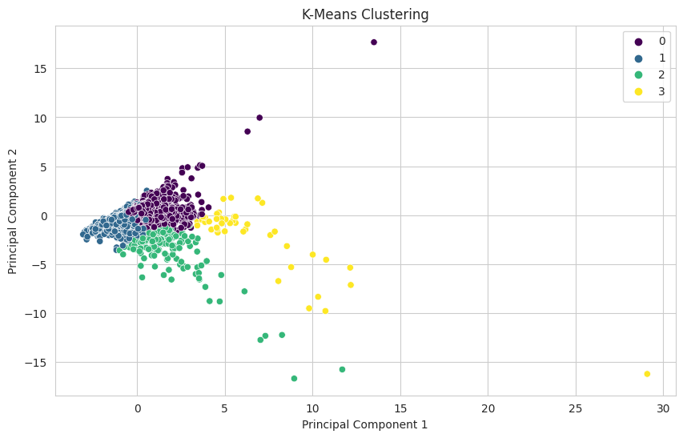

```python
from sklearn.decomposition import PCA
import seaborn as sns

# Reduce data to two dimensions for visualization
pca = PCA(n_components=2)
data_pca = pca.fit_transform(data_scaled)

# Create a scatter plot of K-means clustering results
plt.figure(figsize=(10, 6))
sns.scatterplot(x=data_pca[:, 0], y=data_pca[:, 1], hue=cluster_labels_kmeans, palette='viridis', legend='full')
plt.title('K-Means Clustering')
plt.xlabel('Principal Component 1')
plt.ylabel('Principal Component 2')
plt.show()
```

Basically, the 'kmeans' function performs K-means clustering on the given DataFrame 'df' with k clusters.

It initializes the centroids randomly from the data points in df. It then iteratively updates the centroids until they no longer change.

##### To improve the results, several strategies could be employed, such as:

##### Multiple Initializations: Run the K-means algorithm multiple times with different initial centroids and choose the result with the lowest within-cluster sum of squares.

##### K-means++ Initialization: Use the K-means++ method for initializing centroids to ensure they are spread out across the data space.

##### Feature Engineering: Transform or scale the features in a way that might lead to better clustering results.

# 9. sklearn.cluster

```python
from sklearn.cluster import KMeans

# Apply K-means clustering using sklearn.cluster
kmeans_sklearn = KMeans(n_clusters=k, random_state=42)
cluster_labels_sklearn = kmeans_sklearn.fit_predict(data_scaled)

# Display the first few cluster labels
cluster_labels_sklearn[:20]
```

```
array([2, 2, 2, 2, 2, 2, 2, 2, 0, 0, 0, 2, 0, 0, 2, 0, 2, 0, 0, 0],
      dtype=int32)
```

##### The KMeans class from scikit-learn provides a robust implementation of the K-means algorithm, including optimizations and additional features such as multiple initializations and the K-means++ method for smart centroid initialization.

# 10. kNN Function

##### The k-Nearest Neighbors (kNN) algorithm is a type of instance-based learning that can be used for classification and regression. In this case, we will use it for classification.

##### The predictKNN function will take the following parameters:

##### k: The number of nearest neighbors to consider.

##### data_point: A vector of r numbers representing the data point to be classified.

##### data: A dataframe with r columns containing the feature values.

##### labels: A vector of labels corresponding to the classification of each row in data.

##### The function will return the predicted classification for the data point. We'll use the Euclidean distance to measure the closeness between points.

```python
from collections import Counter

def predictKNN(k, data_point, data, labels):
    """
    k-Nearest Neighbors classification.

    Parameters:
    k (int): The number of nearest neighbors to consider.
    data_point (np.array): A vector of r numbers representing the data point to be classified.
    data (pd.DataFrame): A dataframe with r columns containing the feature values.
    labels (np.array): A vector of labels for classification.

    Returns:
    int: The predicted classification for the data point.
    """
    # Calculate Euclidean distances between the data point and all points in the dataset
    distances = np.linalg.norm(data.values - data_point, axis=1)

    # Get indices of the k nearest neighbors
    k_neighbors_indices = np.argpartition(distances, k)[:k]

    # Get labels of the k nearest neighbors
    k_neighbor_labels = labels[k_neighbors_indices]

    # Return the most common label among the k neighbors
    return Counter(k_neighbor_labels).most_common(1)[0][0]

# Generate random data points and run the predictKNN function
np.random.seed(42)
results = []
for _ in range(5):
    random_data_point = np.random.rand(data_scaled.shape[1])
    predicted_label = predictKNN(k=3, data_point=random_data_point, data=data_scaled, labels=cluster_labels_sklearn)
    results.append((random_data_point, predicted_label))

# Display the results
results
```

```
[(array([0.37454012, 0.95071431, 0.73199394, 0.59865848]), 2),
 (array([0.15601864, 0.15599452, 0.05808361, 0.86617615]), 2),
 (array([0.60111501, 0.70807258, 0.02058449, 0.96990985]), 2),
 (array([0.83244264, 0.21233911, 0.18182497, 0.18340451]), 2),
 (array([0.30424224, 0.52475643, 0.43194502, 0.29122914]), 2)]
```

## 11. Project Report

### * Insights from Data Visualization

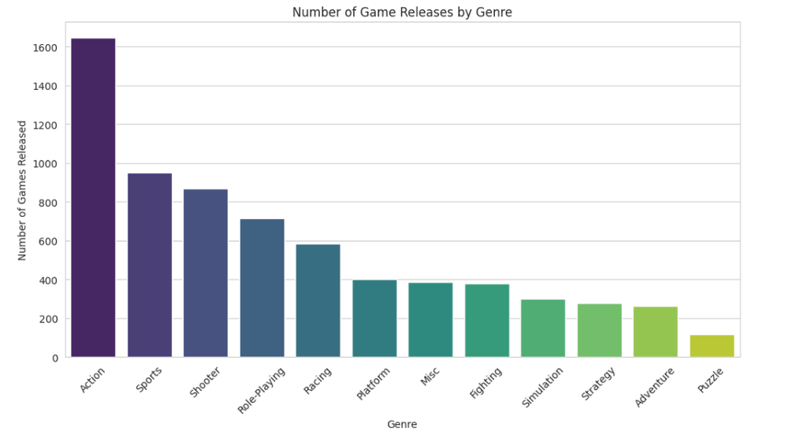

##### The bar plot above illustrates the number of game releases across different genres. Key observations include:

- Action and Sports: These genres have the highest number of releases, indicating their popularity among developers and publishers.
- Role-Playing and Shooter: These genres also have a significant number of releases, showcasing their appeal to a broad audience.
- Puzzle and Strategy: These genres have fewer releases compared to others, which might reflect a more niche audience or specific gameplay preferences

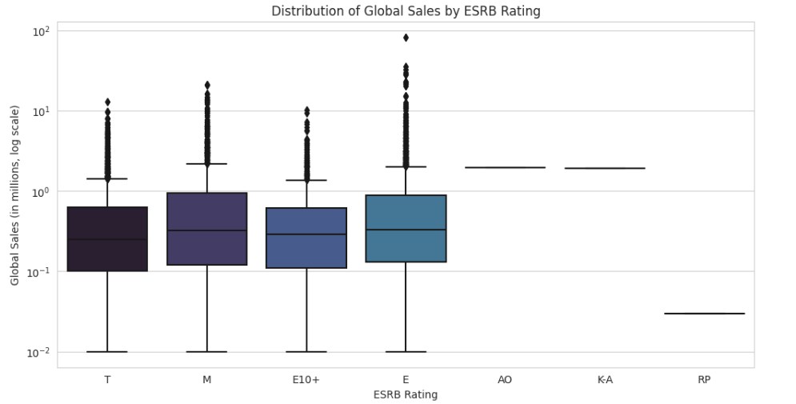

## * Hierarchical Clustering: A Strategic Approach to Market Segmentation

##### In a quest to gain a more nuanced understanding of the gaming market, we applied hierarchical clustering techniques to our data. This method has successfully carved out distinct market segments that offer a treasure trove of strategic opportunities. These segments, each with its unique characteristics, can be invaluable for creating highly targeted marketing campaigns and making smarter resource allocation decisions. The granularity offered by hierarchical clustering allows you not just to understand the market as monolithic but to delve into micro-markets that can be nurtured for maximum yield.

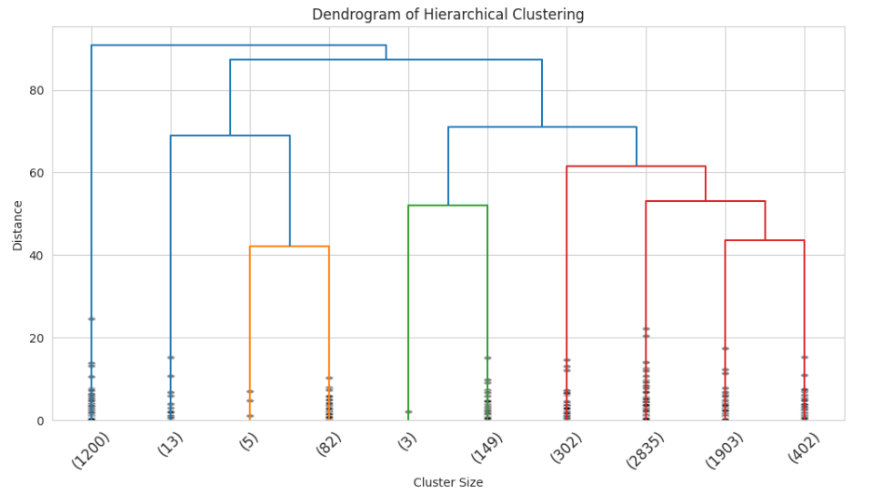

## * K-Means Clustering: Refining Market Segmentation

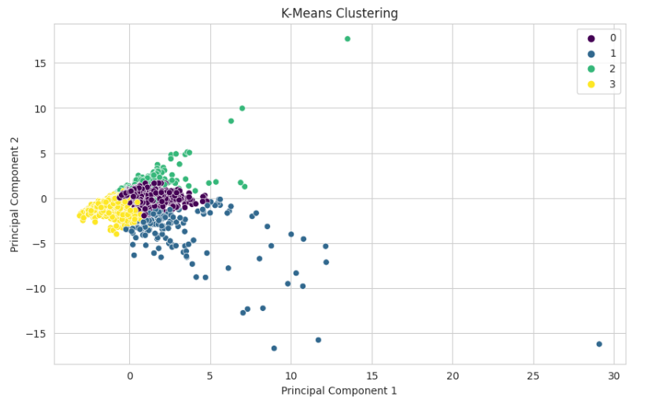

## * Final Thoughts: A Comprehensive Market Blueprint

##### In summary, our rigorous data analysis has generated a holistic understanding of the video game market, teeming with actionable insights. We are confident that these data-driven findings and strategic recommendations will serve as invaluable assets in shaping your future business endeavors.